# Asthama Disease Prediction using Machine Learning !!!!

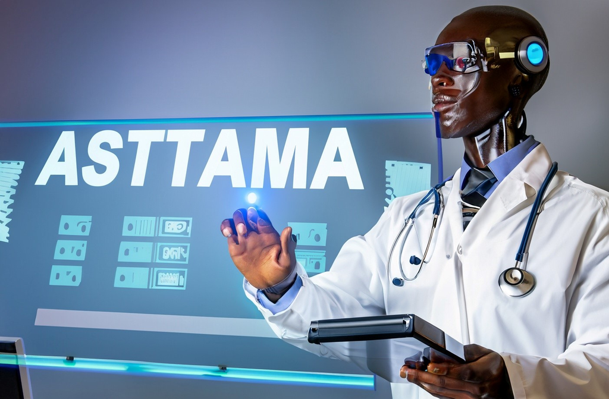

Importing necessary Libraries

```python
import numpy as np
import pandas as pd
import matplotlib.pyplot as plt
import seaborn as sns
import plotly.express as px
import plotly.graph_objects as go
```

```python
import warnings
warnings.filterwarnings('ignore')
```

Reading our DATA

```python
df = pd.read_csv('asthama.csv')
```

EDA

```python
df.head()
```

|  | Tiredness | Dry-Cough | Difficulty-in-Breathing | Sore-Throat | None_Sympton | Pains | Nasal-Congestion | Runny-Nose | None_Experiencing | Age_0-9 | Age_10-19 | Age_20-24 | Age_25-59 | Age_60+ | Gender_Female | Gender_Male | Severity_Mild | Severity_Moderate | Severity_None |
| --- | --- | --- | --- | --- | --- | --- | --- | --- | --- | --- | --- | --- | --- | --- | --- | --- | --- | --- | --- |
| 0 | 1 | 1 | 1 | 1 | 0 | 1 | 1 | 1 | 0 | 1 | 0 | 0 | 0 | 0 | 0 | 1 | 1 | 0 | 0 |
| 1 | 1 | 1 | 1 | 1 | 0 | 1 | 1 | 1 | 0 | 1 | 0 | 0 | 0 | 0 | 0 | 1 | 1 | 0 | 0 |
| 2 | 1 | 1 | 1 | 1 | 0 | 1 | 1 | 1 | 0 | 1 | 0 | 0 | 0 | 0 | 0 | 1 | 1 | 0 | 0 |
| 3 | 1 | 1 | 1 | 1 | 0 | 1 | 1 | 1 | 0 | 1 | 0 | 0 | 0 | 0 | 0 | 1 | 0 | 1 | 0 |
| 4 | 1 | 1 | 1 | 1 | 0 | 1 | 1 | 1 | 0 | 1 | 0 | 0 | 0 | 0 | 0 | 1 | 0 | 1 | 0 |

```python
df.tail()
```

|  | Tiredness | Dry-Cough | Difficulty-in-Breathing | Sore-Throat | None_Sympton | Pains | Nasal-Congestion | Runny-Nose | None_Experiencing | Age_0-9 | Age_10-19 | Age_20-24 | Age_25-59 | Age_60+ | Gender_Female | Gender_Male | Severity_Mild | Severity_Moderate | Severity_None |
| --- | --- | --- | --- | --- | --- | --- | --- | --- | --- | --- | --- | --- | --- | --- | --- | --- | --- | --- | --- |
| 316795 | 0 | 0 | 0 | 0 | 1 | 0 | 0 | 0 | 1 | 0 | 0 | 0 | 0 | 1 | 0 | 0 | 0 | 0 | 0 |
| 316796 | 0 | 0 | 0 | 0 | 1 | 0 | 0 | 0 | 1 | 0 | 0 | 0 | 0 | 1 | 0 | 0 | 0 | 0 | 0 |
| 316797 | 0 | 0 | 0 | 0 | 1 | 0 | 0 | 0 | 1 | 0 | 0 | 0 | 0 | 1 | 0 | 0 | 0 | 0 | 1 |
| 316798 | 0 | 0 | 0 | 0 | 1 | 0 | 0 | 0 | 1 | 0 | 0 | 0 | 0 | 1 | 0 | 0 | 0 | 0 | 1 |
| 316799 | 0 | 0 | 0 | 0 | 1 | 0 | 0 | 0 | 1 | 0 | 0 | 0 | 0 | 1 | 0 | 0 | 0 | 0 | 1 |

```python
df.shape
```

```
(316800, 19)
```

```python
df.columns
```

```
Index(['Tiredness', 'Dry-Cough', 'Difficulty-in-Breathing', 'Sore-Throat',
       'None_Sympton', 'Pains', 'Nasal-Congestion', 'Runny-Nose',
       'None_Experiencing', 'Age_0-9', 'Age_10-19', 'Age_20-24', 'Age_25-59',
       'Age_60+', 'Gender_Female', 'Gender_Male', 'Severity_Mild',
       'Severity_Moderate', 'Severity_None'],
      dtype='object')
```

```python
df.duplicated().sum()
```

```
311040
```

```python
df.isnull().sum()
```

```
Tiredness                  0
Dry-Cough                  0
Difficulty-in-Breathing    0
Sore-Throat                0
None_Sympton               0
Pains                      0
Nasal-Congestion           0
Runny-Nose                 0
None_Experiencing          0
Age_0-9                    0
Age_10-19                  0
Age_20-24                  0
Age_25-59                  0
Age_60+                    0
Gender_Female              0
Gender_Male                0
Severity_Mild              0
Severity_Moderate          0
Severity_None              0
dtype: int64
```

```python
df.info()
```

```
<class 'pandas.core.frame.DataFrame'>
RangeIndex: 316800 entries, 0 to 316799
Data columns (total 19 columns):
 #   Column                   Non-Null Count   Dtype
---  ------                   --------------   -----
 0   Tiredness                316800 non-null  int64
 1   Dry-Cough                316800 non-null  int64
 2   Difficulty-in-Breathing  316800 non-null  int64
 3   Sore-Throat              316800 non-null  int64
 4   None_Sympton             316800 non-null  int64
 5   Pains                    316800 non-null  int64
 6   Nasal-Congestion         316800 non-null  int64
 7   Runny-Nose               316800 non-null  int64
 8   None_Experiencing        316800 non-null  int64
 9   Age_0-9                  316800 non-null  int64
 10  Age_10-19                316800 non-null  int64
 11  Age_20-24                316800 non-null  int64
 12  Age_25-59                316800 non-null  int64
 13  Age_60+                  316800 non-null  int64
 14  Gender_Female            316800 non-null  int64
 15  Gender_Male              316800 non-null  int64
 16  Severity_Mild            316800 non-null  int64
 17  Severity_Moderate        316800 non-null  int64
 18  Severity_None            316800 non-null  int64
dtypes: int64(19)
memory usage: 45.9 MB
```

```python
df.describe()
```

|  | Tiredness | Dry-Cough | Difficulty-in-Breathing | Sore-Throat | None_Sympton | Pains | Nasal-Congestion | Runny-Nose | None_Experiencing | Age_0-9 | Age_10-19 | Age_20-24 | Age_25-59 | Age_60+ | Gender_Female | Gender_Male | Severity_Mild | Severity_Moderate | Severity_None |
| --- | --- | --- | --- | --- | --- | --- | --- | --- | --- | --- | --- | --- | --- | --- | --- | --- | --- | --- | --- |
| count | 316800.000000 | 316800.000000 | 316800.000000 | 316800.000000 | 316800.000000 | 316800.000000 | 316800.000000 | 316800.000000 | 316800.000000 | 316800.000000 | 316800.000000 | 316800.000000 | 316800.000000 | 316800.000000 | 316800.000000 | 316800.000000 | 316800.000000 | 316800.000000 | 316800.000000 |
| mean | 0.500000 | 0.562500 | 0.500000 | 0.312500 | 0.062500 | 0.363636 | 0.545455 | 0.545455 | 0.090909 | 0.200000 | 0.200000 | 0.200000 | 0.200000 | 0.200000 | 0.333333 | 0.333333 | 0.250000 | 0.250000 | 0.250000 |
| std | 0.500001 | 0.496079 | 0.500001 | 0.463513 | 0.242062 | 0.481046 | 0.497930 | 0.497930 | 0.287480 | 0.400001 | 0.400001 | 0.400001 | 0.400001 | 0.400001 | 0.471405 | 0.471405 | 0.433013 | 0.433013 | 0.433013 |
| min | 0.000000 | 0.000000 | 0.000000 | 0.000000 | 0.000000 | 0.000000 | 0.000000 | 0.000000 | 0.000000 | 0.000000 | 0.000000 | 0.000000 | 0.000000 | 0.000000 | 0.000000 | 0.000000 | 0.000000 | 0.000000 | 0.000000 |
| 25% | 0.000000 | 0.000000 | 0.000000 | 0.000000 | 0.000000 | 0.000000 | 0.000000 | 0.000000 | 0.000000 | 0.000000 | 0.000000 | 0.000000 | 0.000000 | 0.000000 | 0.000000 | 0.000000 | 0.000000 | 0.000000 | 0.000000 |
| 50% | 0.500000 | 1.000000 | 0.500000 | 0.000000 | 0.000000 | 0.000000 | 1.000000 | 1.000000 | 0.000000 | 0.000000 | 0.000000 | 0.000000 | 0.000000 | 0.000000 | 0.000000 | 0.000000 | 0.000000 | 0.000000 | 0.000000 |
| 75% | 1.000000 | 1.000000 | 1.000000 | 1.000000 | 0.000000 | 1.000000 | 1.000000 | 1.000000 | 0.000000 | 0.000000 | 0.000000 | 0.000000 | 0.000000 | 0.000000 | 1.000000 | 1.000000 | 0.250000 | 0.250000 | 0.250000 |
| max | 1.000000 | 1.000000 | 1.000000 | 1.000000 | 1.000000 | 1.000000 | 1.000000 | 1.000000 | 1.000000 | 1.000000 | 1.000000 | 1.000000 | 1.000000 | 1.000000 | 1.000000 | 1.000000 | 1.000000 | 1.000000 | 1.000000 |

We have only 1's and 0's

```python
df.nunique()
```

```
Tiredness                  2
Dry-Cough                  2
Difficulty-in-Breathing    2
Sore-Throat                2
None_Sympton               2
Pains                      2
Nasal-Congestion           2
Runny-Nose                 2
None_Experiencing          2
Age_0-9                    2
Age_10-19                  2
Age_20-24                  2
Age_25-59                  2
Age_60+                    2
Gender_Female              2
Gender_Male                2
Severity_Mild              2
Severity_Moderate          2
Severity_None              2
dtype: int64
```

DATA VISUALIZATION COMES INTO THE PICTURE . .

.

.

Count plot for individual coloums

.

```
Count Plot for  Tiredness
```

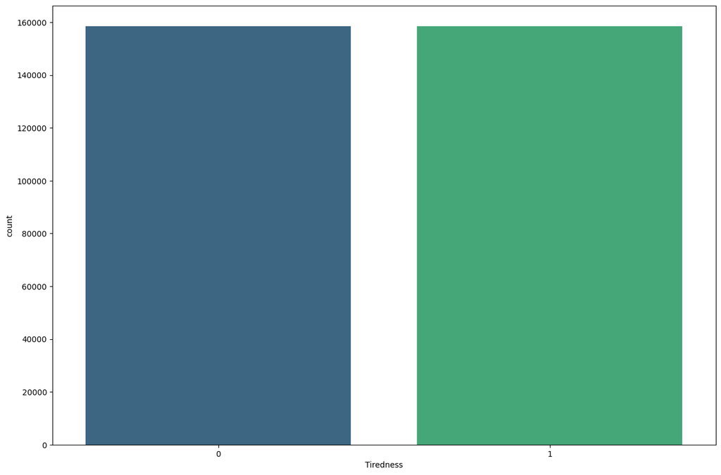

```
Count Plot for  Dry-Cough
```

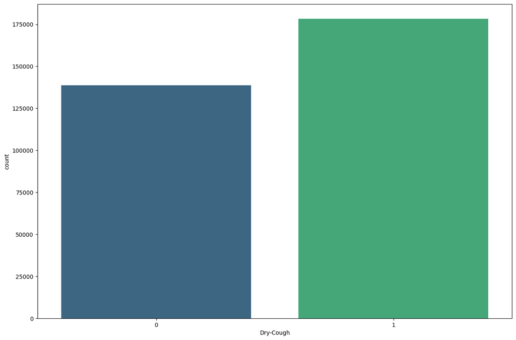

```
Count Plot for  Difficulty-in-Breathing
```

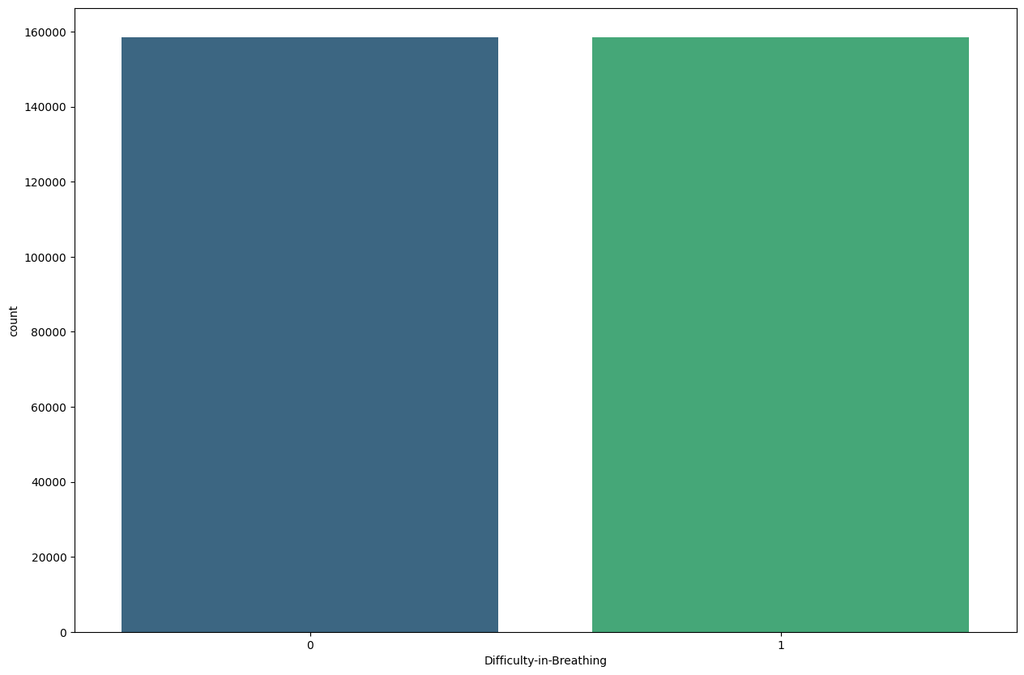

```
Count Plot for  Sore-Throat
```

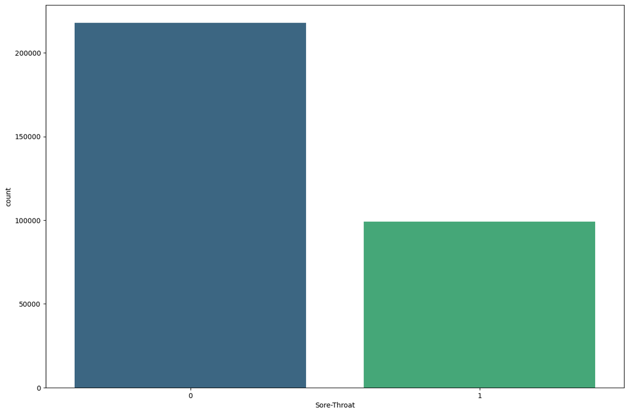

```
Count Plot for  None_Sympton
```

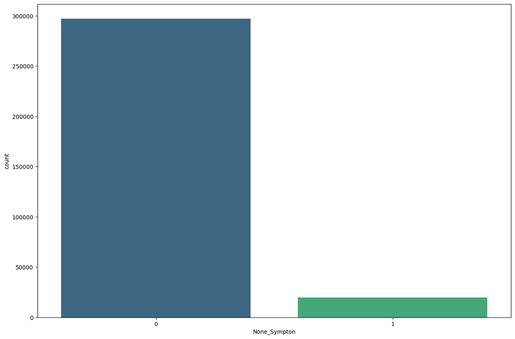

```
Count Plot for  Pains
```

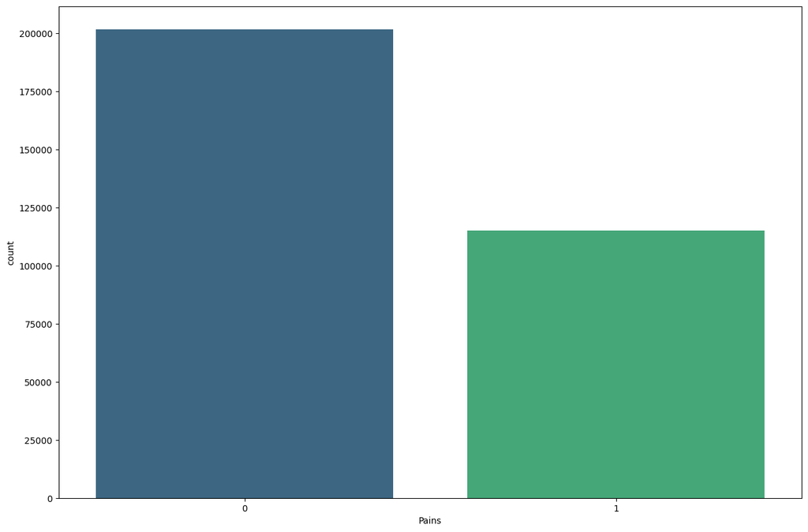

```
Count Plot for  Nasal-Congestion
```

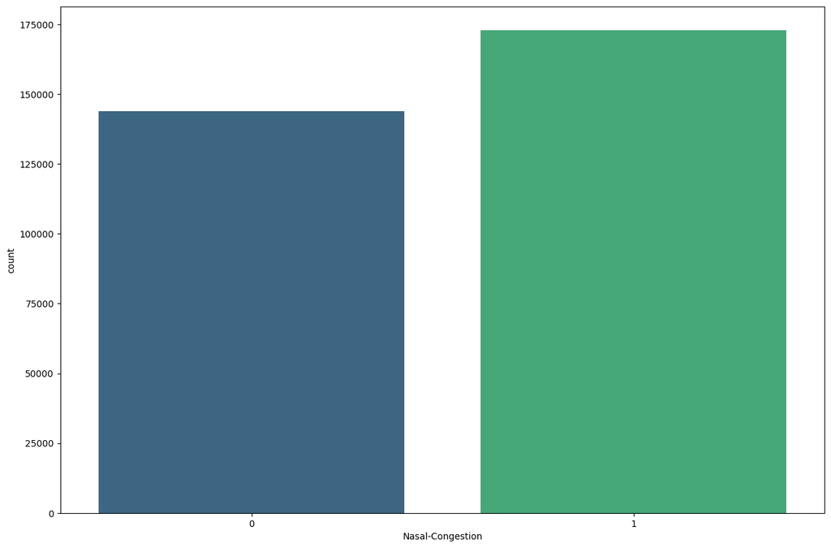

```
Count Plot for  Runny-Nose
```

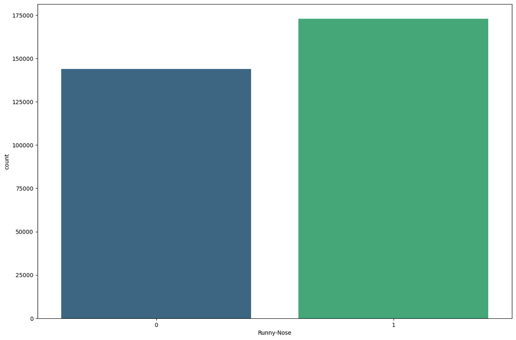

```
Count Plot for  None_Experiencing
```

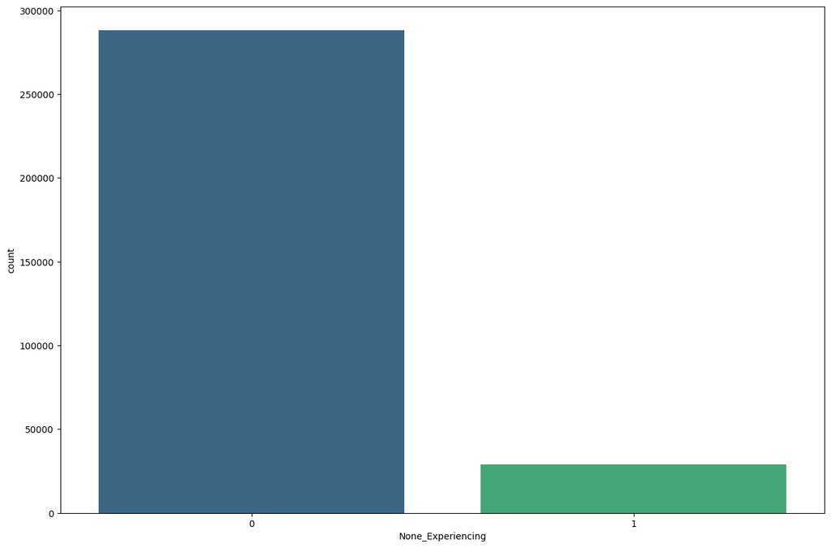

```
Count Plot for  Age_0-9
```

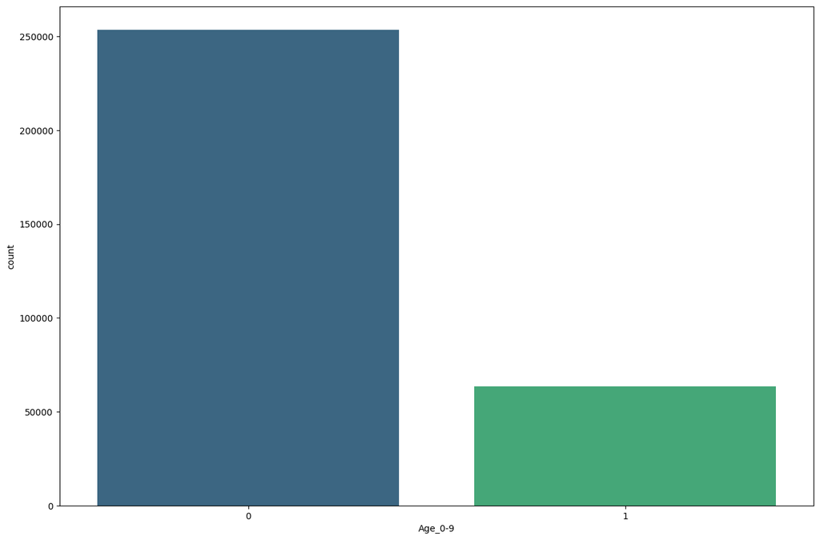

```
Count Plot for  Age_10-19
```

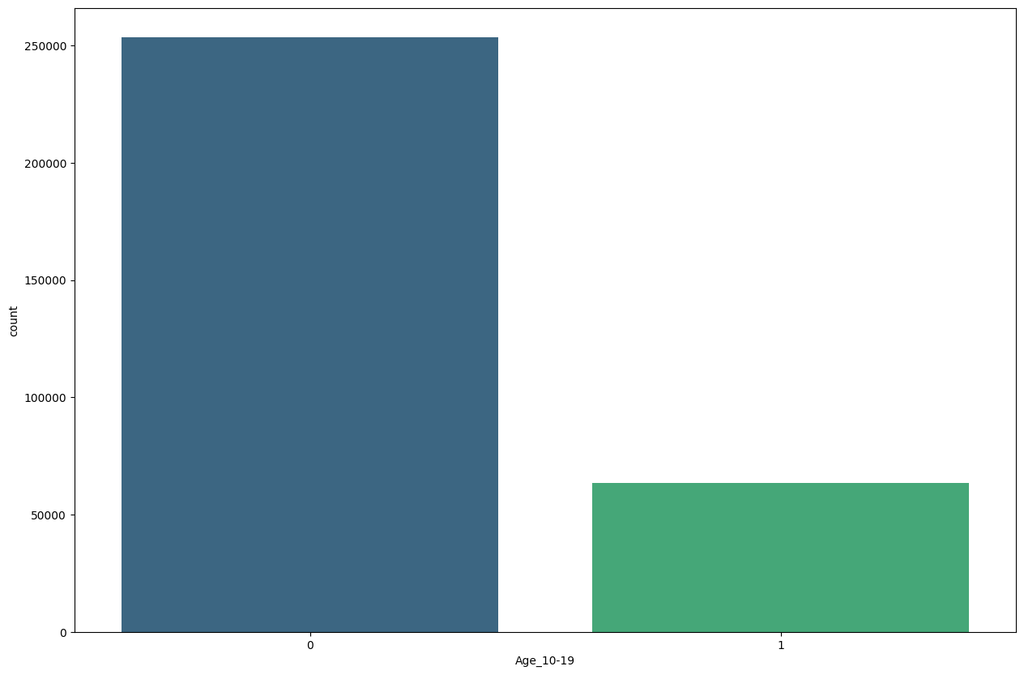

```
Count Plot for  Age_20-24
```

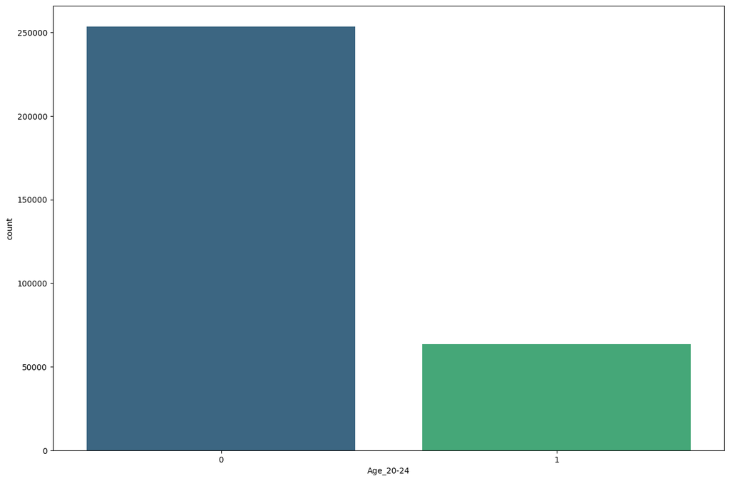

```
Count Plot for  Age_25-59
```

[7 more figures not shown]

```python
for i in df.columns:
    print("Count Plot for " , i)
    plt.figure(figsize=(15,10))
    sns.countplot(x = df[i] , data = df , palette = "viridis")
    plt.show()
    print('\n')
```

PIE plot for individual coloums

.

autopct: This parameter is a string or function used to label the wedges (to break them apart) with their numeric value.

```
Pie plot for: Tiredness
```

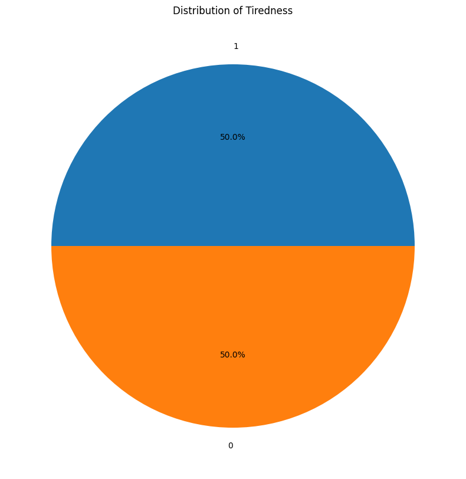

```
Pie plot for: Dry-Cough
```

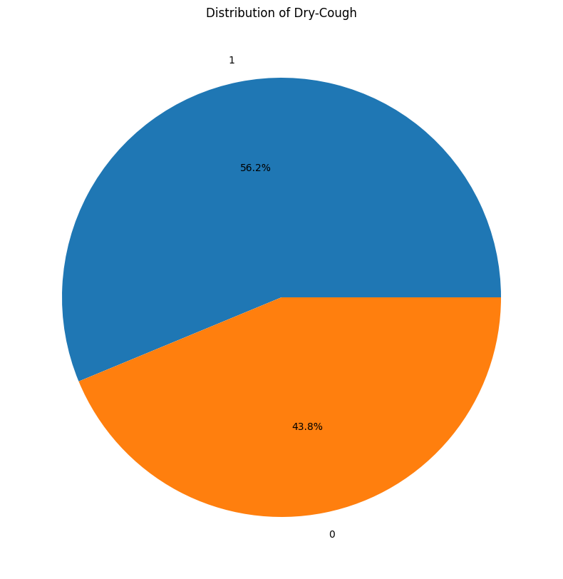

```
Pie plot for: Difficulty-in-Breathing
```

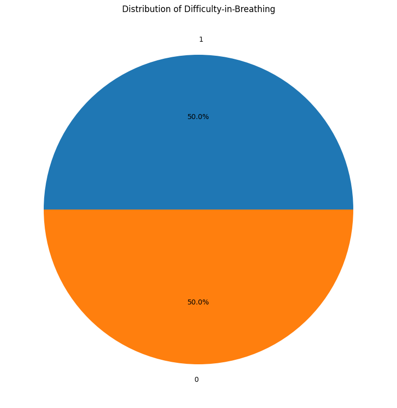

```
Pie plot for: Sore-Throat
```

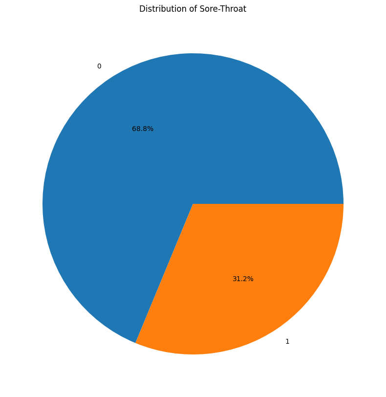

```
Pie plot for: None_Sympton
```

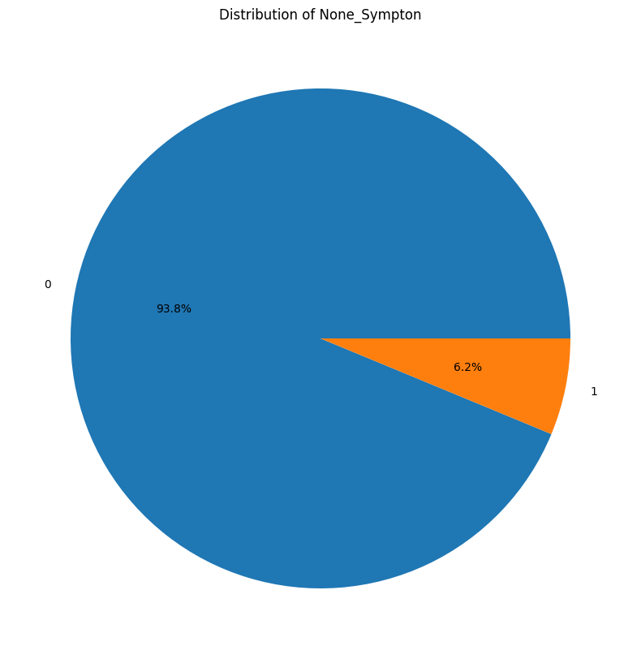

```
Pie plot for: Pains
```

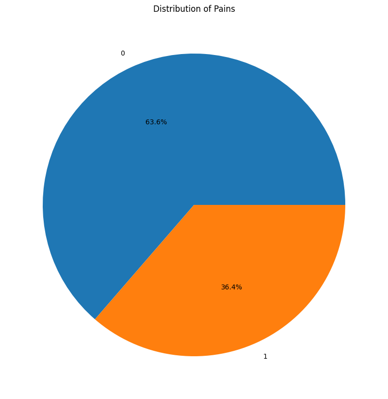

```
Pie plot for: Nasal-Congestion
```

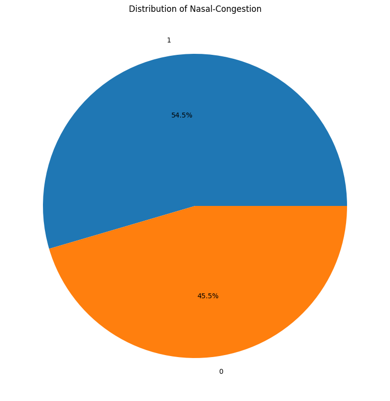

```
Pie plot for: Runny-Nose
```

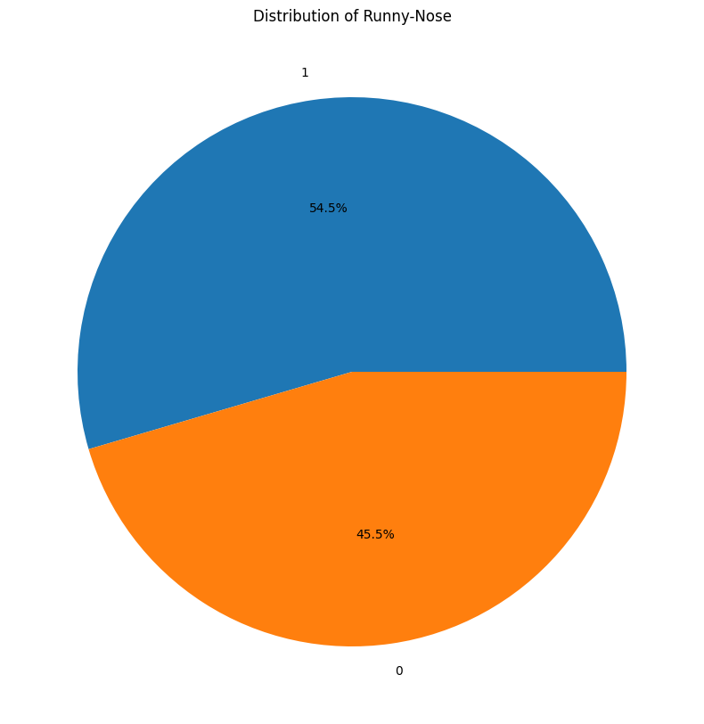

```
Pie plot for: None_Experiencing
```

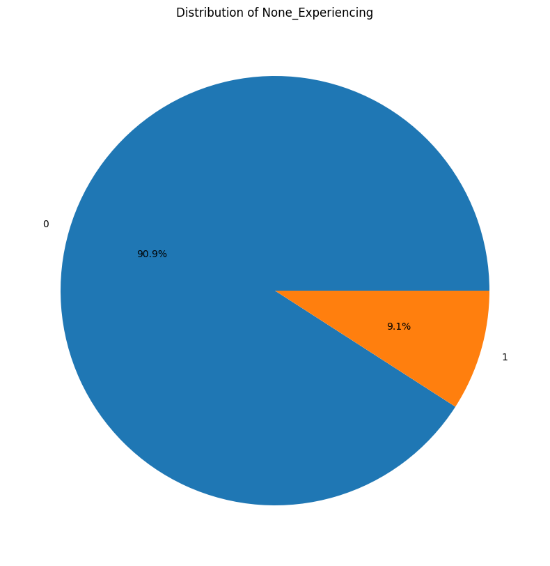

```
Pie plot for: Age_0-9
```

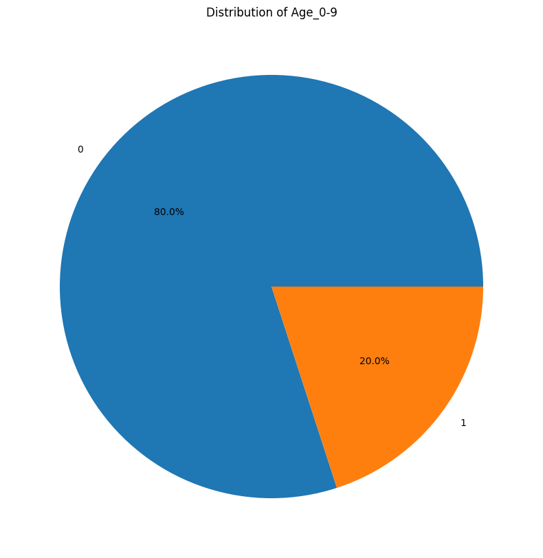

```
Pie plot for: Age_10-19
```

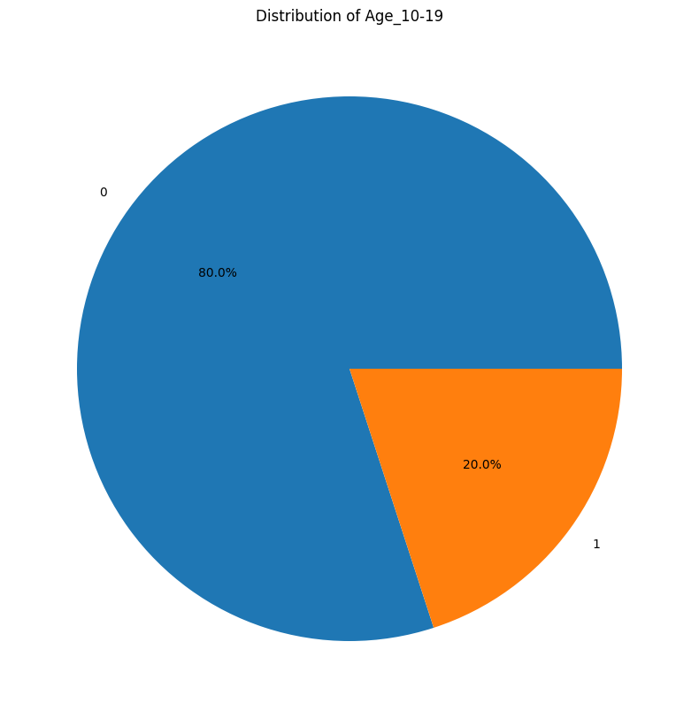

```
Pie plot for: Age_20-24
```

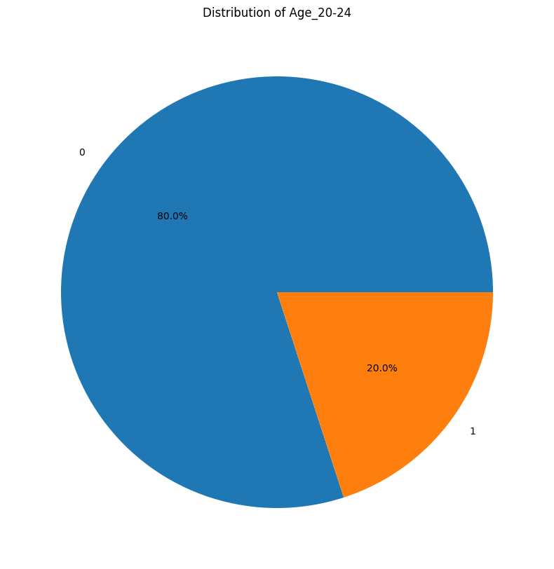

```
Pie plot for: Age_25-59
```

[7 more figures not shown]

```python
for i in df.columns:
    print('Pie plot for:', i)
    plt.figure(figsize=(20, 10))
    df[i].value_counts().plot(kind='pie', autopct='%1.1f%%')
    plt.title('Distribution of ' + i)
    plt.ylabel('')
    plt.show()
    print('\n')
```

BAR plot for individual coloums

.

.index means the Name

.valuecounts means the values

```python
for i in df.columns:
    fig = go.Figure(data = [go.Bar(x = df[i].value_counts().index ,
                                   y = df[i].value_counts())]
                    )
    fig.update_layout(

        title = i,
        xaxis_title = i,
        yaxis_title = "Count"

        )

    fig.show()
```

PIE(Distribution) plot for individual coloums

.

```python
for i in df.columns:
    print("Pie plot for ," , i)

    fig = px.pie(df , names=i , title = "Distribution of"  + i )
    fig.show()

    print('\n')
```

```
Pie plot for , Tiredness
```

```
Pie plot for , Dry-Cough
```

```
Pie plot for , Difficulty-in-Breathing
```

```
Pie plot for , Sore-Throat
```

```
Pie plot for , None_Sympton
```

```
Pie plot for , Pains
```

```
Pie plot for , Nasal-Congestion
```

```
Pie plot for , Runny-Nose
```

```
Pie plot for , None_Experiencing
```

```
Pie plot for , Age_0-9
```

```
Pie plot for , Age_10-19
```

```
Pie plot for , Age_20-24
```

```
Pie plot for , Age_25-59
```

```
Pie plot for , Age_60+
```

```
Pie plot for , Gender_Female
```

```
Pie plot for , Gender_Male
```

```
Pie plot for , Severity_Mild
```

```
Pie plot for , Severity_Moderate
```

```
Pie plot for , Severity_None
```

DATA ASSIMILATION

.

Structuring the data

DROP columns which wont contribute to features

```python
df = df.drop(['Severity_None'] , axis = 1)
```

.idxmax(axis=1): This part of the code uses the idxmax function to find the column label (either 'Severity_Mild' or 'Severity_Moderate') that contains the maximum value for each row along the horizontal axis (axis=1). In other words, for each row in the DataFrame, it identifies which severity is the highest (either 'Mild' or 'Moderate').

```python
df['Asthma_Severity'] = df[['Severity_Mild', 'Severity_Moderate']].idxmax(axis=1)
```

Defined dictionary called severity_mappings that maps the values from two keys, 'Severity_Mild' and 'Severity_Moderate,' to corresponding values 'Mild' and 'Moderate,' respectively.

```python
severity_mappings = {
    'Severity_Mild' : 'Mild' ,
    'Severity_Moderate' :  'Moderate'
}
```

```python
print(severity_mappings)
```

```
{'Severity_Mild': 'Mild', 'Severity_Moderate': 'Moderate'}
```

```python
df['Asthma_Severity'] = df['Asthma_Severity'].map(severity_mappings)
```

```python
df['Asthma_Severity']
```

```
0             Mild
1             Mild
2             Mild
3         Moderate
4         Moderate
            ...
316795        Mild
316796        Mild
316797        Mild
316798        Mild
316799        Mild
Name: Asthma_Severity, Length: 316800, dtype: object
```

Converting to 1's and 0's like our DATA

```python
severity_mappings =  {

    "Mild" : 0,
    "Moderate" : 1,
}
```

```python
df['Asthma_Severity'] = df['Asthma_Severity'].map(severity_mappings)
```

```python
df['Asthma_Severity'].value_counts()
```

```
0    237600
1     79200
Name: Asthma_Severity, dtype: int64
```

Visualize the New Df

Count plot

.

```
Countplot for : Asthma_Severity
```

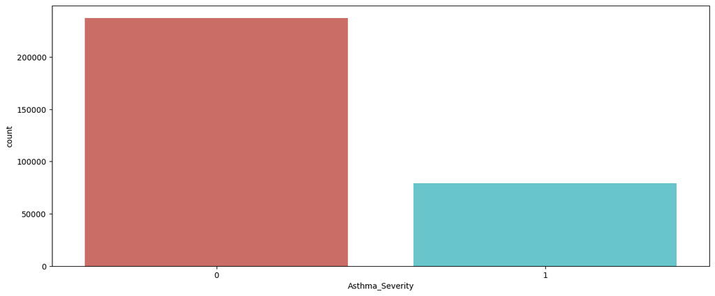

```python
print('Countplot for :' , 'Asthma_Severity')
plt.figure(figsize=(15,6))
sns.countplot(x=df['Asthma_Severity'] , data = df , palette='hls')
```

PIE PLOT

.

```
Pie plot for: Asthma_Severity
```

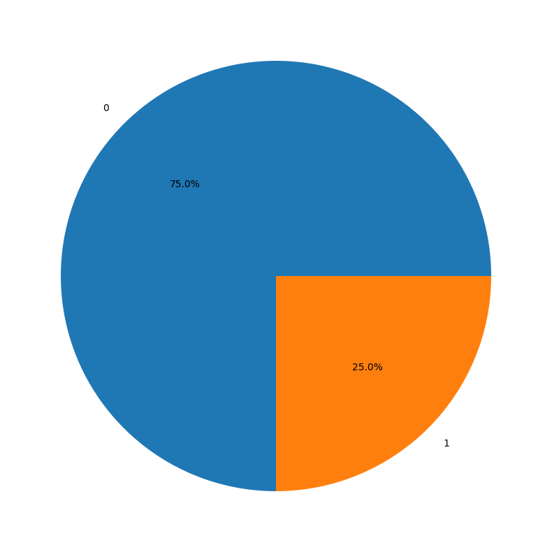

```python
print('Pie plot for:', 'Asthma_Severity')
plt.figure(figsize=(20, 10))
df['Asthma_Severity'].value_counts().plot(kind='pie', autopct='%1.1f%%')
plt.ylabel('')
plt.show()
```

BAR PLOT

.

```python
fig = go.Figure(data=[go.Bar(x=df['Asthma_Severity'].value_counts().index,
                                 y=df['Asthma_Severity'].value_counts())])
fig.update_layout(title='Asthma_Severity', xaxis_title='Asthma_Severity',
                  yaxis_title="Count")
fig.show()
```

```python
print('Pie plot for:', 'Asthma_Severity')
fig = px.pie(df, names='Asthma_Severity')
fig.show()
```

```
Pie plot for: Asthma_Severity
```

```python
df.columns
```

```
Index(['Tiredness', 'Dry-Cough', 'Difficulty-in-Breathing', 'Sore-Throat',
       'None_Sympton', 'Pains', 'Nasal-Congestion', 'Runny-Nose',
       'None_Experiencing', 'Age_0-9', 'Age_10-19', 'Age_20-24', 'Age_25-59',
       'Age_60+', 'Gender_Female', 'Gender_Male', 'Severity_Mild',
       'Severity_Moderate', 'Asthma_Severity'],
      dtype='object')
```

severity_levels = ['Severity_Mild', 'Severity_Moderate']:

This line creates a list called severity_levels containing the names of two columns from the DataFrame df. These columns are 'Severity_Mild' and 'Severity_Moderate.'

severity_distribution = df[severity_levels].sum():

This line calculates the sum of values in the columns specified in the severity_levels list. In this case, it calculates the sum of values in the 'Severity_Mild' and 'Severity_Moderate' columns.

```python
severity_levels = ['Severity_Mild', 'Severity_Moderate']
severity_distribution = df[severity_levels].sum()
```

```python
severity_distribution
```

```
Severity_Mild        79200
Severity_Moderate    79200
dtype: int64
```

Drop as we dont need it anymore

```python
df = df.drop(['Severity_Mild','Severity_Moderate'], axis = 1)
```

```python
symptoms = ['Tiredness', 'Dry-Cough', 'Difficulty-in-Breathing', 'Sore-Throat', 'Pains', 'Nasal-Congestion', 'Runny-Nose']
symptom_counts = df[symptoms].sum()
```

```python
symptoms
```

```
['Tiredness',
 'Dry-Cough',
 'Difficulty-in-Breathing',
 'Sore-Throat',
 'Pains',
 'Nasal-Congestion',
 'Runny-Nose']
```

```python
symptom_counts
```

```
Tiredness                  158400
Dry-Cough                  178200
Difficulty-in-Breathing    158400
Sore-Throat                 99000
Pains                      115200
Nasal-Congestion           172800
Runny-Nose                 172800
dtype: int64
```

```python
age_groups = ['Age_0-9', 'Age_10-19', 'Age_20-24', 'Age_25-59', 'Age_60+']
age_distribution = df[age_groups].sum()
```

```python
age_groups
```

```
['Age_0-9', 'Age_10-19', 'Age_20-24', 'Age_25-59', 'Age_60+']
```

```python
age_distribution
```

```
Age_0-9      63360
Age_10-19    63360
Age_20-24    63360
Age_25-59    63360
Age_60+      63360
dtype: int64
```

```python
gender_groups = ['Gender_Female' , 'Gender_Male']
gender_distribution = df[gender_groups].sum()
```

```python
gender_distribution
```

```
Gender_Female    105600
Gender_Male      105600
dtype: int64
```

CREATING DIFFERENT TYPES OF PLOTS for :

Symptoms

AGE

GENDER

.

BAR PLOT

To see the count of specific Symptoms

.

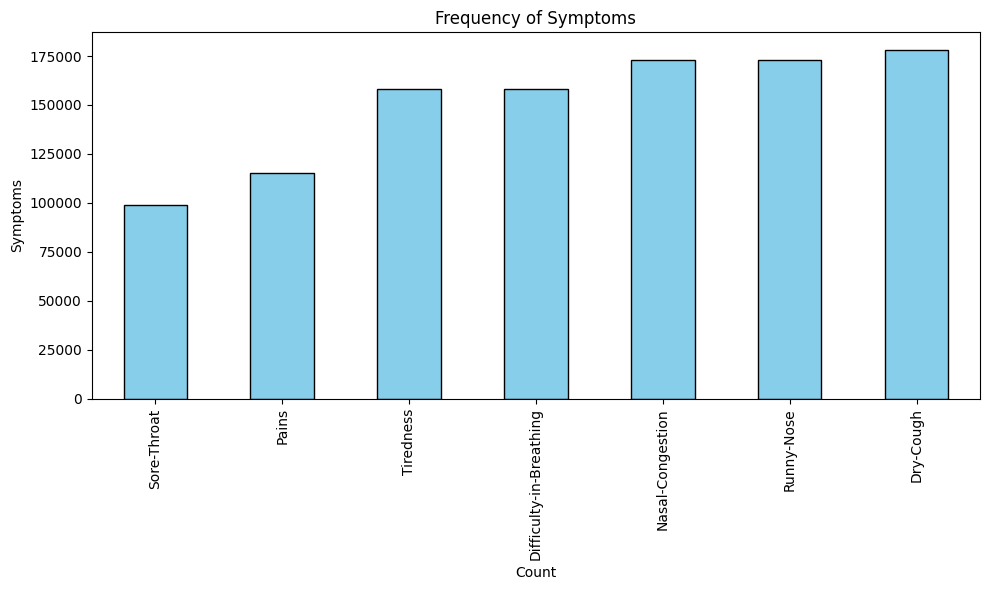

```python
fig, ax = plt.subplots(figsize=(10, 6))

symptom_counts.sort_values().plot(kind='bar', ax=ax, color='skyblue',
                                  edgecolor='black')
ax.set_title('Frequency of Symptoms')
ax.set_xlabel('Count')
ax.set_ylabel('Symptoms')

plt.tight_layout()
plt.show()
```

PIE PLOT

.

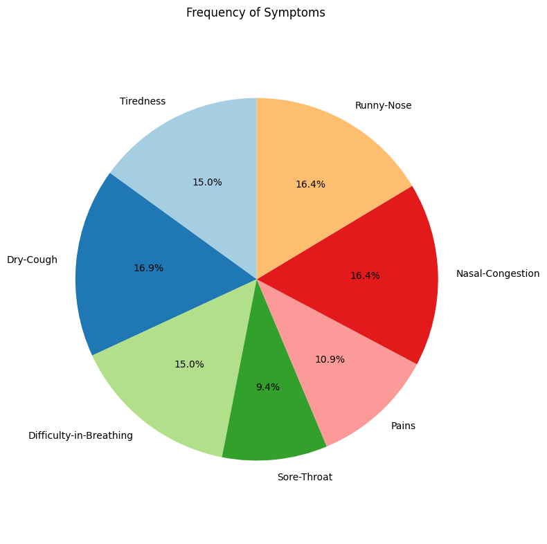

```python
fig, ax = plt.subplots(figsize=(8, 8))
ax.pie(symptom_counts, labels=symptom_counts.index, autopct='%1.1f%%',
       startangle=90,
       colors=plt.cm.Paired(range(len(symptom_counts))))
ax.set_title('Frequency of Symptoms')
plt.axis('equal')
plt.tight_layout()
plt.show()
```

BAR PLOT

.

```python
fig = px.bar(symptom_counts, x=symptom_counts.index, y=symptom_counts.values,
             labels={'x': 'Symptoms', 'y': 'Count'},
             title='Frequency of Symptoms', color_discrete_sequence=['skyblue'])
fig.update_layout(xaxis_tickangle=-45)
fig.show()
```

WE CAN SEE above DRY COUGH IS THE most common symptom and highest in numbers

```python
custom_colors = ['#1f77b4', '#ff7f0e', '#2ca02c', '#d62728', '#9467bd', '#8c564b', '#e377c2', '#7f7f7f', '#bcbd22', '#17becf']
fig = px.pie(symptom_counts, values=symptom_counts.values, names=symptom_counts.index,
             title='Frequency of Symptoms', color_discrete_sequence=custom_colors)
fig.show()
```

PLOT OF AGE DISTRIBUTION